# Differential Expression Pathway Analysis

## Pathway Analysis

First, I collected the gene set assocaited with the Microglial Cell Activation GO term (GO:0001774). I retrieved these manually to generate the heatmap and stored them in `clean_data/20_DE_analysis/microglial_activation_GO_genes.txt`. I retrieved values from the differential expression analysis for the genes from the GO term and created a heatmap based on the fold change observed for the gene in each subtype of patients when compared to controls and MCI patients.

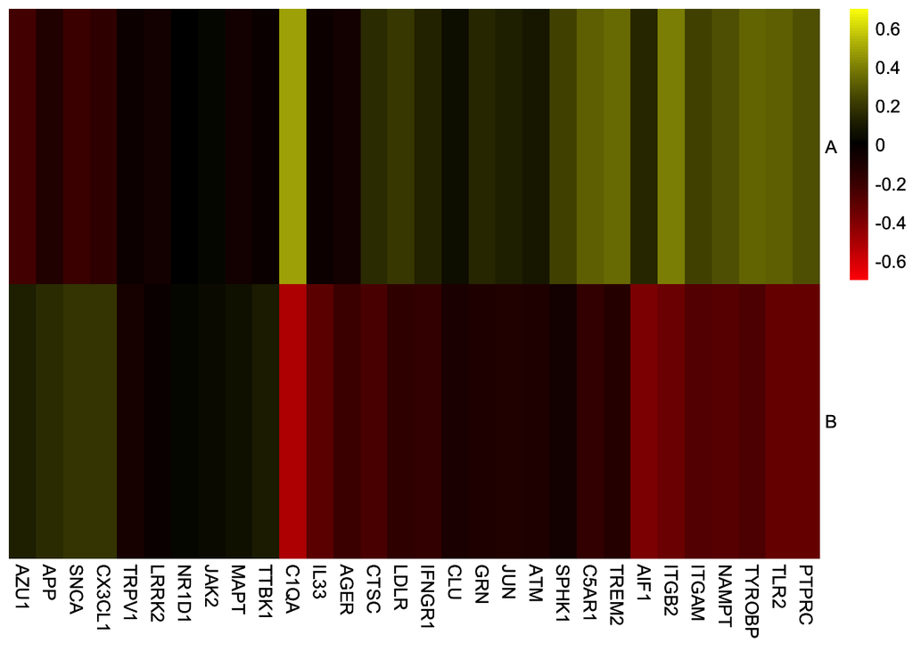

```r
(p <- pheatmap(
  heat.mtx,
  cluster_rows=F,
  cluster_cols=T,
  treeheight_col=0,
  color=colorRampPalette(c("red", "black", "yellow"))(101),
  border_color=F,
  breaks=seq(-0.7, 0.7, length.out=101)
))
```

```r
ggsave(filename="results/8_DE_pathway_analysis/GO_microglia_activation_heat.svg", plot=p, width=13, height=4)
```

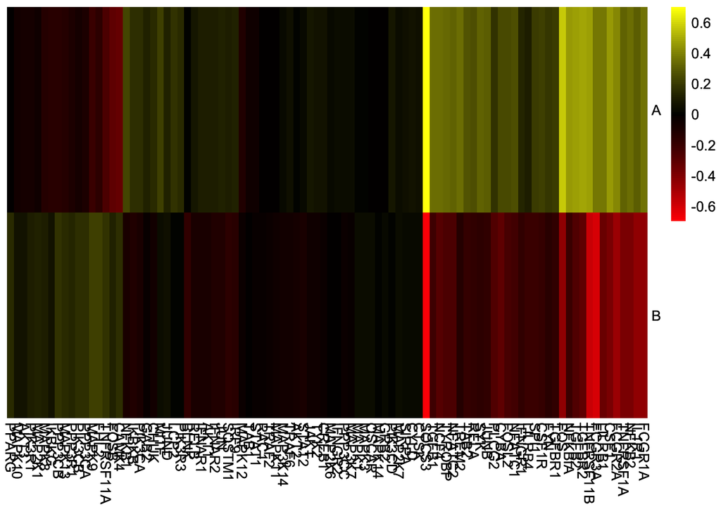

```r
(p <- pheatmap(
  heat.mtx,
  cluster_rows=F,
  cluster_cols=T,
  treeheight_col=0,
  color=colorRampPalette(c("red", "black", "yellow"))(100),
  border_color=F,
  breaks=seq(-0.7, 0.7, length.out=101)
))
```

```r
ggsave(filename="results/8_DE_pathway_analysis/KEGG_microglia_activation_heat.svg", plot=p, width=15, height=4)
```

## Reactome Pathway Analysis

Here I perform Reactome Pathway analysis on the differentially expressed genes for each subtype. I have a adjusted p-value cutoff of 0.1 and a fold change cutoff of 0.5.

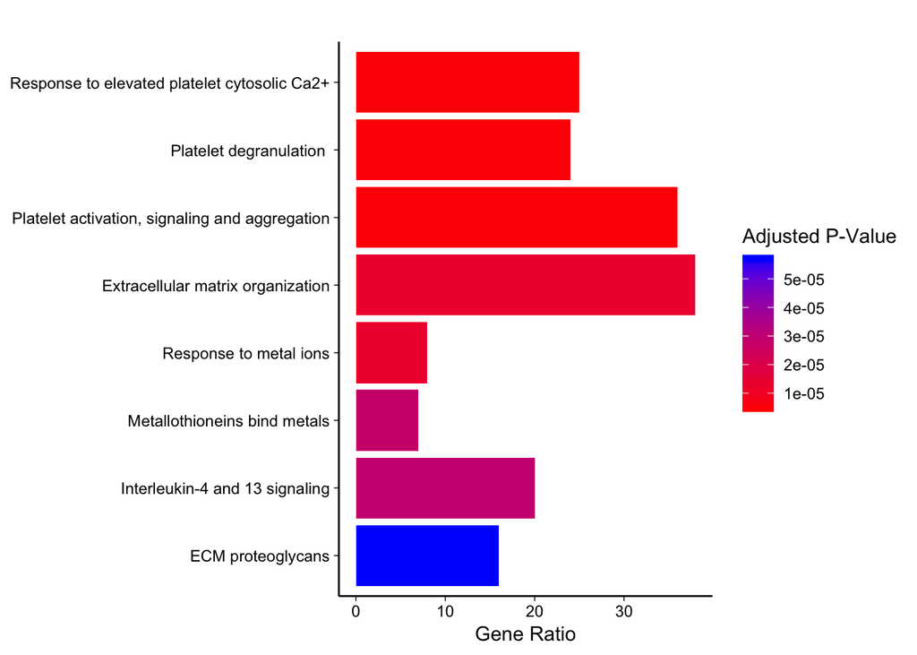

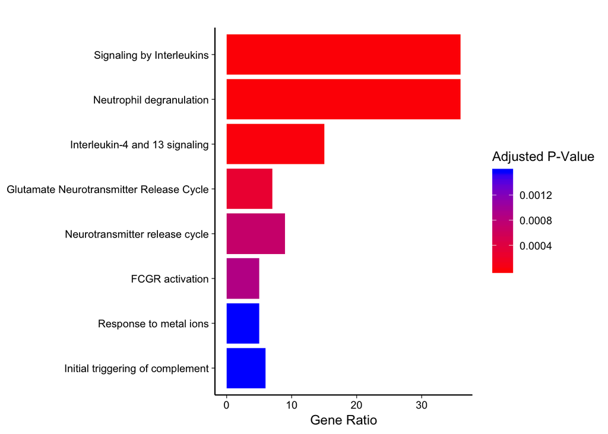

```r
lapply(reacts, function(x) {
  barplot(x) +
    labs(y="Gene Ratio") +
    guides(fill=guide_colorbar("Adjusted P-Value")) +
    basic_theme_big
})
```

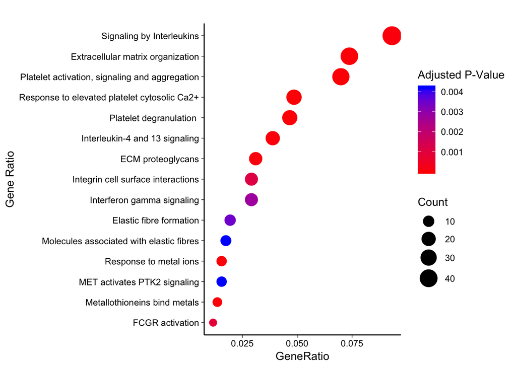

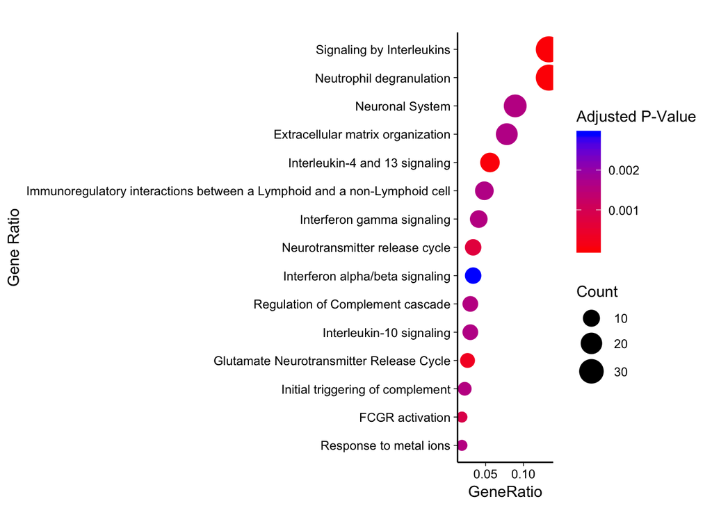

```r
lapply(reacts, function(x) {
  dotplot(x, showCategory=15) +
    guides(color=guide_colorbar("Adjusted P-Value")) +
    labs(y="Gene Ratio") +
    basic_theme_big
})
```

I was interested in directly comparing the Reactome pathways for subtype A and B.

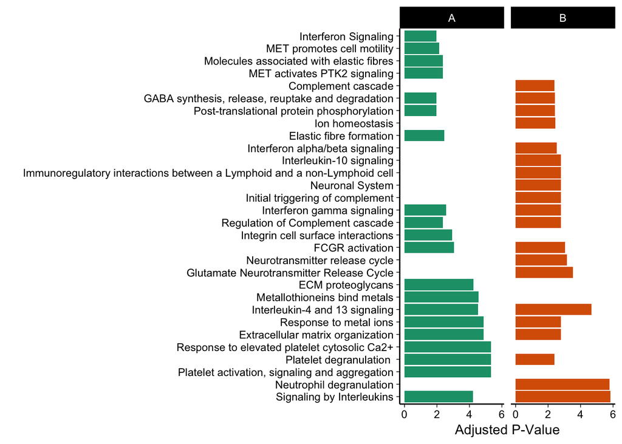

```r
ggplot(plot.data) +
  geom_bar(aes(x=Description, y=Log.P.Value, fill=Subtype), stat="identity") +
  scale_fill_brewer(palette="Dark2") +
  guides(fill=F) +
  coord_flip() +
  xlab("") + ylab("Adjusted P-Value") +
  facet_grid(~Subtype) +
  basic_theme
```

```r
ggsave(filename="results/8_DE_pathway_analysis/de_reactome_annots.svg", width=12, height=7)
```

## KEGG Enrichment Analysis

I ran KEGG enrichment to assess pathways that are highly differentially expressed. I use a adjusted p-value cutoff of 0.1.

One specific pathway we are interested in is the TREM2/TYROBP pathway, annotated as the KEGG Osteoclast Differentiation pathway (KEGG:hsa04380). We will search for this pathway specifically and assess its enrichment in subtypes A and B.

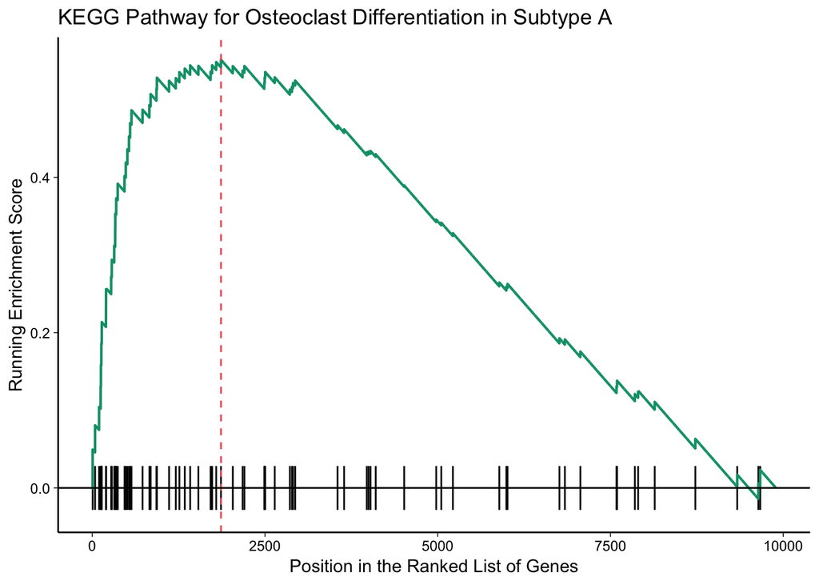

```r
os.d.a <- which(keggs[[1]]$ID == "hsa04380")
p <- gseaplot(keggs[[1]], geneSetID=os.d.a, by="runningScore", title=keggs[[1]]$Description[os.d.a]) +
  basic_theme_big +
  labs(title="KEGG Pathway for Osteoclast Differentiation in Subtype A")
p$layers[[2]]$aes_params = list(colour = "#049e78", size=0.75)
p
```

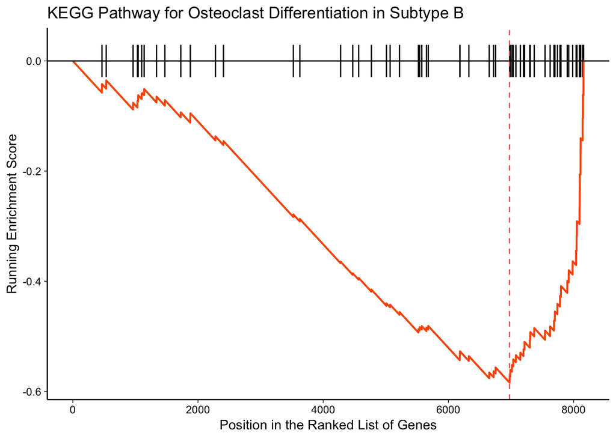

```r
ggsave(filename="results/8_DE_pathway_analysis/osteo_diff_gene_ranks_A.svg", plot=p, width=10, height=3)

os.d.b <- which(keggs[[2]]$ID == "hsa04380")
q <- gseaplot(keggs[[2]], geneSetID=os.d.b, by="runningScore", title=keggs[[2]]$Description[os.d.b]) +
  basic_theme_big +
  labs(title="KEGG Pathway for Osteoclast Differentiation in Subtype B")
q$layers[[2]]$aes_params = list(colour = "#f85900", size=0.75)
q
```

```r
ggsave(filename="results/8_DE_pathway_analysis/osteo_diff_gene_ranks_B.svg", plot=q, width=10, height=3)
```